# SEI/CADE - 1100178 - Voto Processo Administrativo

**Ministério da Justiça e Segurança Pública - MJSP**

**Conselho Administrativo de Defesa Econômica - CADE**

SEPN 515, Conjunto D, Lote 4, Edifício Carlos Taurisano, - Bairro Asa Norte, Brasília/DF, CEP 70770-504  
Telefone: 61 3031-1283 - www.gov.br/cade

**Processo Administrativo nº 08700.007278/2015-17**

**Representante:** Empresa Brasileira de Infraestrutura Aeroportuária – Infraero

**Representados:** Alimentare Serviços de Restaurante e Lanchonete Ltda., Boa Viagem Cafeteria Ltda., Confraria André Ltda., Delícias da Vovó Ltda., Ventana Manutenção e Serviços Ltda., Cesar Giacomini Evangelista Kinaki, Christian dos Santos Marques Motta, Fabiano Luis Gusso, Gustavo Locks de Pauli, Hugo Evangelista Kinaki, Jean Diego Brunetta, Juliana Osorio Saul e Vitor Hugo dos Santos

**Advogados:** Marcus Ely Soares dos Reis, Rodrigo Pironti Aguirre de Castro, Rafael Porto Lovato, Ciro Brüning e outros.

**Relator****:** Conselheiro Sérgio Costa Ravagnani.

VOTO VISTA - CONSELHEIRO GUSTAVO AUGUSTO FREITAS DE LIMA

VERSÃO PÚBLICA

**voto**

I. CONSIDERAÇÕES INICIAIS

Em homenagem ao princípio constitucional da economicidade aplicado à administração pública, adoto o Relatório elaborado pelo Conselheiro Relator (SEI 1045727) como exposição fática do presente voto.

Quanto ao mérito, adianto que, após análise pormenorizada das circunstâncias e informações acostadas aos autos, da Nota Técnica nº 32/2021 emitida pela Superintendência-Geral, do Parecer Jurídico nº 09/2021 da PFE e do PARECER Nº 09/2021/WA/MPF/CADE, não restam dúvidas quanto à formação de cartel clássico pelas empresas Representadas, considerando toda a sólida estrutura engendrada para a participação das empresas nos certames licitatórios objeto do Processo.

Assim, acompanho os pontos essenciais trazidos pelo ponderado voto apresentado pelo Conselheiro-Relator, sendo certo que a presente divergência se circunscreve, tão somente, a três pontos específicos. No mais, estou completamente de acordo com a tese e conclusões expostas no referido voto, o qual bem analisou as questões de fato e de Direito postas nos autos.

Aponto, ainda, que concordo plenamente com a proposta do Conselheiro-Relator de se efetuar a consulta aos órgãos da Receita Federal do Brasil para se verificar a capacidade econômica das pessoas físicas representadas, efetivamente considerando essas informações na dosimetria da pena.

Dito isso, em apertada síntese, são apenas três os pontos que trago à discussão no presente voto-vista:

A questão do *standard* probatório exigível para a penalização da pessoa física quanto à conduta de cartel, notadamente em relação ao representado HUGO KINAKI;

A necessidade de sistematização para a dosimetria da pena das pessoas físicas, considerando a atual jurisprudência do Tribunal do CADE sobre o tema e a necessidade e se ter linhas gerais que sejam de amplo conhecimento dos atores envolvidos, para se garantir a previsibilidade e segurança jurídica das condenações proferidas no âmbito deste Conselho; e

O pedido do Ministério Público Federal para que a penalidade de proibição de contratar com instituições financeiras oficiais e participar de licitação seja aplicada por prazo não inferior a 5 (cinco) anos, como previsto no inciso II do art. 38 da Lei 12.529, de 2011.

Proponho, no presente voto, a defesa de aplicação de valores moderadamente mais elevados em relação às multas aplicáveis às pessoas físicas como método mais eficiente de dissuasão de práticas colusivas, questão essa que já vem sendo debatida e aplicada no Tribunal do CADE. Nesse contexto, apresento uma proposta de metodologia para cálculo de multa para pessoas físicas em caso de infrações anticoncorrenciais, considerando a adequação com a sua capacidade econômica. Tal metodologia, se acolhida, permitirá orientar novas condenações, mantendo-se a equidade, proporcionalidade e tratamento isonômico.

Por fim, aplico a metodologia ora proposta à dosimetria da pena no caso concreto, destacando em tópico próprio as considerações relativas a cada um dos representados.

**II. ANÁLISE DE MÉRITO EM RELAÇÃO AO REPRESENTADO HUGO KINAKI**

Conforme se extrai dos documentos e informações acostados aos autos, o Representado HUGO KINAKI era sócio administrador das empresas Boa Viagem Cafeteria Ltda. e Delícias da Vovó Ltda, e possuía relação de parentesco com alguns dos demais representados. Essa situação pode ser verificada do esquema gráfico abaixo, devidamente apresentado nas manifestações da Superintendência-Geral:

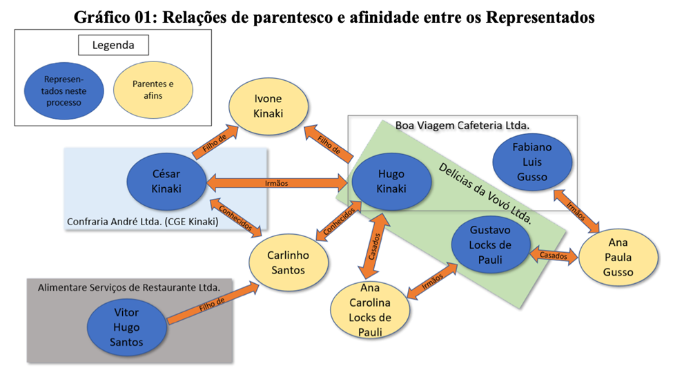

Ocorre que, para além dos laços de afinidade, parentesco e do fato de ser representante legal de duas das empresas representadas, não existe nos autos nenhum documento que comprove ou demonstre sua anuência, ou mesmo sua ciência, com o conluio em questão.

Além de não existirem provas como trocas de mensagens, e-mails ou demais correspondências em seu nome, também não há qualquer registro de sua assinatura nos documentos de participação nos certames, nem em qualquer outro documento coletado ao longo da instrução processual.

As únicas informações existentes a respeito do representado em tela são de seu grau de parentesco ou afinidade com os demais representados, e seu registro como sócio administrador de duas empresas participantes do cartel.

A esse respeito, ressalto que não discordo do racional desenvolvido pela Superintendência-Geral e pelo Conselheiro Relator quanto a esses últimos pontos. É dizer, o fato de ser sócio administrador das empresas Delícias da Vovó e Boa Viagem, e de possuir grau de parentesco com os demais representados e pessoas comprovadamente envolvidas no conluio demonstram, minimamente, uma probabilidade de sua ciência dos acordos ilícitos.

No entanto, em termos de *standard* probatório e fixação de provas aptas a gerar uma condenação por parte da autoridade antitruste, é preciso se ter muita cautela, devendo ser exigida a prova de dolo ou culpa, no caso de punição da pessoa física. Em outras palavras, não se admite a culpa objetiva no caso de condenação de pessoas físicas por condutas de cartel clássico. Notadamente quando se verifica que existem outros sócios e administradores reconhecidamente envolvidos na conduta ilícita, os quais podem ter agido de forma isolada, sem a ciência ou anuência do ora representado.

Nesse contexto, entendo que não é possível condenar um indivíduo por ato ilícito colusivo de que não se tenha provas concretas de sua efetiva participação, ciência, omissão ou anuência com o conluio. Não se trata, aqui, da discussão da necessidade de a prova ser direta ou indireta, uma vez que entendo plenamente possível a condenação por cartel com base na prova indireta, a depender do conjunto probatório. O que se está falando é que a condenação, nesse caso, deve vir acompanhada de provas concretas de prática da conduta pelo representado, de forma omissiva ou comissiva, ou que se prove ao menos a existência de negligência ou imprudência por parte do mesmo, não sendo possível, no caso de pessoa física, a condenação com base em presunção.

Não há no processo administrativo sancionador a possibilidade de responsabilização objetiva de pessoas físicas, de forma que é preciso se considerar, necessariamente, a sistemática da teoria da culpabilidade e dos elementos subjetivos de dolo para a responsabilização dos indivíduos representados. E ao analisar com cautela os presentes autos, entendo que não se formou um conjunto mínimo de provas que justificasse a condenação do representado HUGO KINAKI.

O fato de ser, à época, sócio administrador de ambas as empresas não é prova suficiente de seu envolvimento no cartel em exame, tampouco seu grau de parentesco e afinidade com os demais representados. Estes fatores podem figurar como indicativos, denotando uma razoável probabilidade de envolvimento, capaz de justificar a condução de uma investigação. Contudo, tais indícios não são, por si só, provas aptas à sua condenação.

O próprio legislador, ao editar os comandos normativos da Lei de Defesa da Concorrência, buscou determinar no *caput* do art. 36 que os indivíduos administradores ou ocupantes de quaisquer outros postos de decisão e comando não sejam responsabilizados pelo simples fato de ocuparem essa posição na empresa. O sistema de responsabilização da pessoa física depende, necessariamente, do contexto probatório e da efetiva existência de provas de participação da pessoa física no ilícito praticado – entendimento este completamente pacífico e consolidado na jurisprudência deste Tribunal, como se pode verificar do trecho abaixo:

De acordo com a Lei 12.529/2011, a existência de culpa ou dolo é exigida para condenação de pessoas físicas por força do art. 37, inciso III. É certo que esse padrão é diverso daquele imposto às pessoas jurídicas que podem ser responsabilizadas independentemente de culpa (art. 36, *caput*). Assim, para verificar a participação de pessoas jurídicas em infrações à ordem econômica, basta constatar a sua responsabilidade objetiva, sem que seja necessário ponderar sobre a culpa ou dolo do agente no cometimento da prática. Distintamente, o regime de responsabilização das pessoas físicas é subjetivo, no qual é imprescindível constatar que a pessoa tenha incorrido em culpa ou dolo na realização da infração (Voto-Vogal Conselheira Paula Farani no Processo Administrativo nº 08700.011474/2014-05, §29 - SEI 0763981).

Feitas essas considerações, não vislumbro a possibilidade de condenar o Representado HUGO KINAKI pela participação no conluio ora apurado, motivo pelo qual entendo e voto pelo arquivamento dos presentes autos em relação a ele, por falta de provas.

iii. **SISTEMATIZAÇÃO DAS MULTAS APLICADAS ÀS PESSOAS FÍSICAS**

Este Conselho Administrativo já vem buscando há algum tempo sistematizar a aplicação de multas a pessoas físicas em casos de condenação por cartel, considerando justamente uma aproximação com os padrões de dosimetria de multas utilizados em outras jurisdições e a necessidade de adequação dos valores à capacidade econômica do infrator como forma de cumprir com o efeito dissuasório da pena pecuniária.

No voto do Processo Administrativo de Tubos e Conexões (PA nº 08700.003390/2016-60 - SEI 0974145), o Conselheiro Relator do caso, Luiz Hoffmann, abordou em tópico próprio os critérios de dosimetria utilizados em jurisdições estrangeiras. Nas conclusões parciais sobre os dados colhidos, o Conselheiro identificou alguns padrões utilizados em outros países sobre o aumento das penas pecuniárias, notadamente em relação às pessoas físicas por sua capacidade econômica no Reino Unido:

190. Outro aspecto também notório das jurisdições é a existência de alíquotas adicionais (dissuasórias) para cartéis (denominadas de *entry-fee*) ou, ainda, multiplicadores que são aplicados conforme os critérios de cada jurisdição levando em conta agravantes e atenuantes. Na União Europeia e na França, adota-se uma alíquota adicional de 15-25% do faturamento anual afetado pelo cartel. Nos Estados Unidos, adota-se multiplicadores de 0,75 a 4,00. Na Alemanha, os multiplicadores são aplicados em faixas, conforme o porte econômico da empresa, sendo que, em relação às maiores empresas, o multiplicador pode superar 6 vezes a multa-base. **No Reino Unido, não é estabelecida uma alíquota ou um multiplicador de antemão, mas aponta-se que a multa será aumentada tendo em vista a capacidade econômica do infrator, auferida a partir de informações financeiras**. Em qualquer caso, a majoração ou multiplicação da multa-base pode ficar limitada ao limite legal mencionado anteriormente. **(grifo nosso)**

Nesse mesmo contexto, mas já buscando uma sistematização da aplicação de multa às pessoas físicas, o Conselheiro Sérgio Ravagnani propôs no âmbito do PA nº 08700.003340/2017-63 (“Cartel de Filtros Automotivos”) e do PA nº 08700.009879/2015-64 (“Cartel de Distribuidoras e Revendedoras de Combustíveis em Joinville/SC”) a valoração da condição econômica atual do infrator, a partir de dados concretos obtidos por meio da Receita Federal do Brasil.

Assim, com o objetivo de garantir que a multa aplicada ao infrator não fosse sub ou superdimensionada, o Conselheiro Ravagnani apontou em seu voto como Relator no PA nº 08700.003340/2017-63 (SEI 0974596) que:

256. A partir do julgamento do PA nº 08700.009879/2015-64 (cartel de distribuidoras e revendedoras de combustíveis em Joinville/SC), adoto a postura de requisitar informações sobre renda e patrimônio dos administradores à RFB para valorar a condição prevista no inc. VII do art. 45 da Lei nº 12.529/11, qual seja, a condição econômica do infrator, a fim de que o valor da pena de multa ao administrador não seja subdimensionada a ponto de enfraquecer o *enforcement* do Cade na repressão das infrações contra a ordem econômica, e nem sobredimensionada, ferindo garantias do administrador como a dignidade da pessoa humana e a individualização da pena (art. 1º, inc. III, e art. 5º, inc. XLVI, ambos da Constituição Federal).

257. Naquele julgamento, propus um limite máximo para o valor da pena de multa a administrador, qual seja, o maior valor entre (i) 25% dos rendimentos declarados à RFB no último exercício e (ii) 10% do patrimônio informado a RFB no mesmo período.

Verifico, portanto, que essa iniciativa de sistematização de multas específicas para pessoas físicas já é uma preocupação deste Cade, principalmente considerando a tendência de considerar para tanto os dados obtidos a partir da Receita Federal para aferir a capacidade econômica do representado como dosimetria da pena.

No entanto, não foi proposta, até o momento, uma metodologia específica e própria para tanto, motivo pelo qual reputo relevante esboçar uma sistematização de metodologia para a determinação da dosimetria da pena.

Proponho essa metodologia **não como uma fórmula matemática para engessar o julgamento dos Conselheiros, os quais devem ter a palavra final para avaliar as circunstâncias específicas de cada caso concreto**, mas como um esforço de se aperfeiçoar o corrente marco teórico, dar uma sinalização para os agentes de mercado e garantir previsibilidade e segurança jurídica nos julgados deste Tribunal Administrativo.

De toda sorte, independentemente das linhas gerais ora propostas, defendo que o julgamento final deve ter a **liberdade suficiente para permitir que este Tribunal considere as questões específicas do caso**, devendo a eventual condenação e respectiva dosimetria considerar critérios de proporcionalidade, isonomia, equidade, moralidade administrativa e razoabilidade.

**III.1. Da tendência mundial para o aumento do efeito dissuasório da pena em casos de cartéis**

A presente proposta de sistematização da metodologia de cálculo de multa para pessoas físicas segue uma tendência internacional de conferir uma pena mais elevada em desfavor dos indivíduos participantes de condutas de cartel, considerando o entendimento de que a pena imposta à pessoa física possui o condão de gerar efeitos dissuasórios mais efetivos.

Neste contexto, é possível fazer um paralelo com os clássicos ensinamentos de Jeremy Bentham sobre crimes econômicos:

O lucro do crime é a força que insta o homem à delinquência; a dor do castigo é a força empregada para impedi-lo disso. Se a primeira dessas forças for maior, o crime será cometido; se o segundo, o crime não será cometido<sup>[1]</sup>.

No caso, a adequação do entendimento secular de Bentham revela um raciocínio completamente aplicável aos casos de cartel, que possui a natureza tanto de ilícito administrativo quanto de ilícito penal, notadamente por se tratar de uma conduta onde vantagens e desvantagens integram o cálculo econômicos dos agentes de mercado, que tendem a avaliar questões como risco e retorno ao adotar condutas anticompetitivas. Nestes casos, portanto, o efeito dissuasório do delito está calcado exatamente na “dor do castigo” que lhe será aplicado.

Esse maior poder dissuasório decorrente do aumento das penas individuais também foi apontado por Gregory J. Werden em sua obra *Sanctioning Cartel Activity*, ao introduzir o entendimento de análise econômica do direito, de que a efetividade da “dor do castigo” se encontra em sanções monetárias, e não nas não monetárias, como a prisão:

Para deter as atividades de cartel, as sanções impostas aos participantes do cartel precisam produzir desutilidade suficiente para superar o que estes participantes esperam ganhar com a atividade do cartel.

(...)

A análise econômica do direito penal geralmente conclui que as sanções monetárias são mais eficientes do que as não monetárias, particularmente a prisão. A análise se inicia pela observação de que prisões são caras e que prender pessoas priva a sociedade de sua produtividade. A análise então afirma que qualquer nível de dissuasão desejado poderia ser alcançado sem incorrer em nenhum custo, porque uma multa não teria custos, e uma multa suficientemente grande poderia, geralmente, atingir o mesmo nível de dissuasão do que qualquer sentença de prisão<sup>[2]</sup> .

No ano de 2003, o Comitê Concorrencial da OCDE realizou uma *roundtable* para discutir acerca das sanções em carteis contra pessoas físicas. Naquela oportunidade, uma das principais questões apontadas foi a de que:

Existem evidências empíricas de que sanções corporativas na forma de multas não são quase nunca suficientemente altas para configurar um efeito ótimo de dissuasão, e na maioria dos casos estão substancialmente abaixo deste nível. Nessas circunstâncias, a ameaça de sanções individuais podem fortalecer o incentivo para diretores e empregados a resistir a pressões corporativas de engajamento em atividades ilícitas, e então aumentar os níveis dissuasórios<sup>[3]</sup>.

Nesse contexto, um dos relatórios de cartel analisados na *roundtable* demonstrou a importância de sanções contra indivíduos na luta contra cartéis clássicos, além de que essa área seria a qual o potencial de fortalecimento da lei e das práticas de *enforcement* seria mais significante na maioria dos países.

Apesar de, naquela época, essa noção ainda não ser tão difundida nem praticada na maioria dos países, quase vinte anos depois o cenário mudou completamente, de forma que hoje o entendimento é o de que é preciso aumentar as penas impostas a pessoas físicas<sup>[4]</sup>, ao invés de se impor penas muito elevadas a pessoas jurídicas, que poderiam inclusive causar-lhes problemas como falência e probabilidade de saída do mercado, diminuindo a competição<sup>[5]</sup>.

Contudo, essa imposição de multas mais elevadas às pessoas físicas também não pode se dar de forma arbitrária ou incompatível com a capacidade econômica dos representados, a ponto de se gerar a impossibilidade de seu pagamento. A multa deve gozar, portando, de aplicabilidade.

Para tal fim, entendo como aplicabilidade o fato de a multa dever ser proporcional, exequível e apta a ser efetivamente cobrada pelos meios de execução legalmente disponíveis, considerando o quadro financeiro do representado e sua situação patrimonial. E essa aplicabilidade deve ser determinada de forma simples e previsível.

Sobre o tema, cumpre destacar as lições de Cesare Beccaria<sup>[6]</sup>:

É preferível prevenir os delitos a ter que puni-los; e todo legislador sábio deve antes procurar impedir o mal que repará-lo, pois uma boa legislação não é mais do que a arte de proporcionar aos homens a maior soma de bem-estar possível e livrá-los de todos os pesares que se lhes possam causar, conforme o cálculo dos bens e dos males desta existência.

[...]

Desejais prevenir os crimes? Fazei lei simples e claras; e esteja o país inteiro preparado a armar-se para defendê-las, sem que a minoria de que falamos se preocupe constantemente em destruí-las.

Entendo, ainda, que essa aplicabilidade deva ser equilibrada com a necessidade de efeito dissuasório, considerando que qualquer penalidade aplicada por este Conselho deve ser suficiente para desestimular novas condutas anticoncorrenciais, tanto por parte do próprio acusado, seja por seus pares e demais agentes do mercado. E o melhor efeito dissuasório é a pena ser simples, clara e previsível. Para isso, deve haver regras claras que permitam que o julgador encontre o ponto de equilíbrio em relação ao **binômio “aplicabilidade-efeito dissuasório”**.

III.2. **Racional teórico da proposta de metodologia de cálculo**

Considerando os apontamentos no tópico anterior, adoto, como fundamento do meu voto, um teste composto de duas fases. Na primeira fase, verifico as circunstâncias da conduta, as quais serão consideradas para a fixação da alíquota aplicável. Na segunda fase, verifico, à luz das informações disponíveis no Imposto de Renda da Pessoa Física, ou de outros elementos fáticos relevantes, se o representado possui capacidade econômica para o pagamento da multa e se a multa é financeiramente adequada à capacidade econômica do representado, verificando tanto a aplicabilidade da punição como o desejado efeito dissuasório.

Sendo assim, considerando os padrões de dosimetria que já vem sendo aplicados pelo CADE, e tendo em vista que a infração de cartel, na sua modalidade clássica, deve ser considerada como a infração de maior gravidade na seara concorrencial, proponho as seguintes faixas de alíquotas a serem aplicadas à dosimetria das infrações, na sua primeira fase:

Cartel clássico (“hardcore”) ou cartel de licitação: **de 12 a 20%** da multa aplicada à pessoa jurídica;

Cartel difuso, paralelismo *plus,* demais condutas colusivas e condutas individuais de menor gravidade: **de 1% a 12%** da multa aplicada à pessoa jurídica.

As figuras do cartel clássico e cartel difuso já se encontram suficientemente definidas nos precedentes deste Tribunal Administrativo e não necessitam de maiores digressões.

Quanto às condutas individuais de menor gravidade, designo como sendo as infrações nas quais a **conduta individual da pessoa física representada tenha tido diminuta importância para a concretização da infração por parte da pessoa jurídica**. Também incluo nessa classificação os casos em que a conduta específica do representado tenha causado um grau de lesão baixo à concorrência (art. 45, V), ou não tenha causado lesão significativa, bem como as condutas individuais que possuam baixa reprovabilidade. Afasto dessa classificação os casos em que haja prova de que o representado tenha agido com dolo ou má-fé, tenha tentado ocultar provas e informações, ou tenha buscado atrapalhar os trabalhos da autoridade concorrencial. Claro está que a definição do que se consiste, ou não, conduta individual de menor gravidade depende da avaliação do caso concreto e será melhor emoldurada com os precedentes deste Tribunal Administrativo.

Quanto à estipulação das faixas a serem aplicadas à pessoa física administradora, julgo importante tecer as seguintes considerações. Após definida a modalidade de cartel para o caso concreto, e havendo conjunto probatório suficiente para a condenação da conduta, entendo ser necessário individualizar o cálculo da multa com base nas atenuantes e agravantes verificadas, adotando-se valores médios que podem servir como referência para a dosimetria da penalidade a ser apresentada em concreto.

Para os casos de cartel clássico (*hard core*), o qual apresenta como faixa sugerida de **12% a 20%**, um valor médio de referência seria de **15%**, podendo o Conselheiro-Relator diminuir a alíquota até o limite mínimo de 12% ou aumentar até o limite máximo de 20%, conforme a individualização da conduta para cada pessoa física e as circunstâncias do caso concreto. Em todo caso, deve-se prestigiar a decisão motivada do Relator em face das circunstâncias específicas de cada caso e de eventuais excepcionalidades, sendo certo que tais parâmetros devem servir tão somente como uma referência a ser considerada em cada decisão.

Para os casos de cartéis difusos, paralelismo *plus* e demais condutas colusivas e anticoncorrenciais de média gravidade, a faixa **de 1% a 12%** teria como alíquota média de referência o montante de **6%**, reservando-se a faixa de 1 a 5% para as situações de baixa lesividade ou de presença preponderante de circunstâncias atenuantes. De toda sorte, nesses casos, tem o Relator a prerrogativa de diminuir até o limite mínimo de 1% ou a aumentar até o limite máximo de 12%, considerando, de forma fundamentada, as particularidades de cada caso.

Definidas as faixas e valores de referência, tenho que a determinação da alíquota exata deve ser feita, *a priori*, à luz das circunstâncias agravantes e atenuantes listadas no art. 45 da Lei 12.529, de 2011:

Art. 45. Na aplicação das penas estabelecidas nesta Lei, levar-se-á em consideração:

I - a gravidade da infração;

II - a boa-fé do infrator;

III - a vantagem auferida ou pretendida pelo infrator;

IV - a consumação ou não da infração;

V - o grau de lesão, ou perigo de lesão, à livre concorrência, à economia nacional, aos consumidores, ou a terceiros;

VI - os efeitos econômicos negativos produzidos no mercado;

VII - a situação econômica do infrator; e

VIII - a reincidência.

Excepciono da lista acima apenas a circunstância do inciso VII do artigo acima transcrito (“situação econômica do infrator”), uma vez que a situação econômica do será considerada na fase dois da dosimetria. A depender do resultado da segunda fase, ela poderá ser considerada como limitadora, no caso de carência de capacidade de pagamento (princípio do *ability to pay*), ou como circunstância do agravante, hipótese na qual ela será aplicada na alíquota para manutenção do efeito dissuasório.

Adoto, como parâmetro para aplicação do art. 45 da Lei 12.529/11, a elevação da alíquota, ou sua diminuição, na ordem de 1 a 2% para cada circunstância considerada, agravante ou atenuante, respeitados, decerto, o máximo e o mínimo legal. Nesse mesmo raciocínio, também são incluídos os casos de cartel em que não se verificou a produção de efeitos ou a gravidade da conduta, caso no qual podem ser aplicadas as devidas atenuantes (na ordem de 1% a 2%), nos termos do art. 45, da Lei 12.529/2011.

Ressalto particularmente a situação na qual o infrator tenha um maior **protagonismo ou liderança** na conduta, hipótese na qual reputo que a agravante deve se dar, **preferencialmente,** **na ordem de 5%**.

No caso de reincidência (37, §1º da Lei 12.529, de 2011), entendo que a dobra deve ser aplicada nesta primeira fase, para o posterior cotejo com a capacidade econômica.

No caso específico das pessoas físicas que não sejam administradoras (art. 37, II da Lei 12.529, de 2011), entendo que, na falta de outros elementos que indiquem a necessidade de cominação de pena mais elevada, pode-se utilizar, como referência, a mesma metodologia adotada para o cálculo da multa da pessoa física administradora. Quando necessário, é possível se aplicar, ao final, uma atenuante, na hipótese de a conduta do “não administrador” ser considerada menos gravosa, quando comparada a do administrador. Em todo caso, reputo que devem ser respeitados os limites trazidos pelo inciso II do art. 37 da Lei supramencionada.

Eventual diferenciação entre a penalidade aplicável a administradores e não administradores deve ser ponderada à luz dos fatos concretos, uma vez que não se pode afirmar que necessariamente o administrador atuará de maneira mais gravosa, num eventual conluio. Aliás, é plenamente possível a comprovação de um cenário no qual o infrator não administrador possua participação mais importante no cartel do que os demais. O ponto fulcral dessa argumentação, portanto, é que o fato de o infrator ser ou não administrador da pessoa jurídica sob escrutínio não pode ser uma circunstância que, por si só, determine a gravidade da conduta, a qual deve ser objetivamente verificada.

Definida a multa na primeira fase, que deve se ater às circunstâncias da conduta, adoto a metodologia de, em uma segunda fase, adequar-se o valor da multa à situação econômica do infrator. Para tal fim, entendo que os elementos a serem considerados devam ser o rendimento **anual bruto do infrator e as informações sobre o seu patrimônio**, considerando para tal propósito os dados mais recentes disponíveis ao Cade. Adoto como critério temporal o uso **dos dados financeiros mais recentes** no lugar dos dados referentes à época da conduta ou da instauração do processo administrativo, pois são os dados atuais que melhor revelam a efetiva capacidade econômica do infrator para pagar a penalidade a ele aplicada.

Entendo que, para tal aferição, deverão ser usadas preferencialmente as **informações do Imposto de Renda da Pessoa Física**, a serem requisitadas à Receita Federal. Por tal motivo, julgo desejável que se adote como praxe que, na fase de instrução e investigação, tais dados já sejam solicitados à Receita Federal do Brasil, como forma de se subsidiar a decisão do Tribunal Administrativo.

Também entendo que **poderá o Conselheiro fazer uso de outros meios de prova**, notadamente se os dados financeiros obtidos na declaração do IRPF forem inidôneos ou inverossímeis. Para tal fim, pode o Relator levar em consideração o patrimônio do infrator ou outros elementos de prova admissíveis em Direito.

Para a verificação da capacidade econômica, opino que o valor a ser considerado para efeito da dosimetria é o rendimento bruto total recebido pela pessoa física, incluindo os rendimentos isentos, não tributáveis ou tributados exclusivamente na fonte. Da mesma forma, deve ser considerado o patrimônio do infrator, uma vez que a capacidade econômica é aferível a partir do montante total de recursos econômicos do qual o indivíduo dispõe, compostos, notadamente, por duas principais variáveis: o fluxo de rendimentos que ele aufere anualmente e o patrimônio que possui.

Estabelecido o rendimento anual bruto do infrator, opino que, em regra, a multa a ser aplicada **não** **deva ser superior a** **30% (trinta por cento)** da renda bruta anual do infrator, somados **a 6% (seis por cento) do valor** do seu patrimônio do infrator, considerados os dados e informações disponíveis. Explico, na sequência, o uso desses percentuais.

Em relação aos 30%, esse é o **percentual máximo que vem sendo admitido pelo STJ** em face do superendividamento, já tendo o STJ afirmado que descontos na remuneração superiores a esse montante ferem o mínimo existencial<sup>[7]</sup>.

Por outro lado, apenas considerar o percentual de 30% do rendimento anual do infrator seria estabelecer um limite mais favorável que o adotado pela Jurisprudência pátria. Isso porque os Tribunais, ao usarem o limite de 30%, não limitam esse valor a um único exercício financeiro. Trata-se tão somente de uma trava sobre o rendimento mensal, de forma a se salvaguardar um mínimo de existência digna, mas que se projeta ao longo do tempo, podendo abranger mais do que um exercício financeiro.

Assim, para se melhor adequar o limite jurisprudencial à prática do CADE, como estamos adotando um padrão de limite da renda com base em um único exercício financeiro, a melhor forma de se equilibrar tal limite é adicionar um determinado percentual que se refira ao patrimônio do infrator e traduza economicamente o total da sua capacidade econômica.

Com relação ao percentual de **6% do valor do patrimônio do infrator,** tal proporção se refere aos juros legais da poupança (6% ao ano + TR), que o infrator teria obtido como renda passiva se tivesse deixado seu patrimônio na poupança ou aplicados em títulos públicos, sem risco financeiro significativo. Considerando um investidor racional, o fato de o infrator preferir colocar esse valor em patrimônio, no lugar de gerar uma renda passiva, revela que o seu patrimônio lhe garante um nível de utilidade econômica superior ao que obteria pelo referido investimento. Por tal razão, pode-se inferir que o referido patrimônio equivale, no mínimo, a um rendimento anual desta monta (6% ao ano), razão pela qual se depreende a capacidade econômica de o mesmo arcar com uma penalidade desse patamar.

Nos casos em que a multa resultante da Fase 1 seja superior ao limite de 30% do rendimento anual, acrescido de 6% do patrimônio apurado, entendo que deva caber a este Conselho, preferencialmente, limitá-la a este montante, sempre respeitado o mínimo legal, desde que não existam outros fatores que justifiquem a desconsideração do princípio do *ability to pay*.

Também considero que, à luz da situação econômica dos agentes envolvidos, a multa fixada não deve ser economicamente insignificante, uma que a sanção deve ser dotada de efeito dissuasório.

Nesse contexto, opino que se presume a capacidade econômica elevada em relação ao infrator que possua renda bruta superior a 10 vezes a renda média dos administradores e gerentes, como aferido no PNAD contínua. Em valores atuais, isso significa dizer que o infrator possui rendimento bruto anual superior a R$ 947.180,00 (ou R$ 72.860,00 mensais). Contudo, outros elementos fáticos podem ser considerados para se chegar a mesma conclusão, tendo em vista o patrimônio do infrator, sinais externos de riqueza, controle de empresas com elevado faturamento, desproporção entre a multa e a renda ou patrimônio do infrator e outras circunstâncias do caso concreto, bem como nos casos em que for evidente a desproporção da multa.

Em casos como esse, quando a desproporção da capacidade econômica do infrator indicar ser necessária uma majoração para se conceder um efetivo cunho dissuasório à penalidade, parece-me que a alíquota obtida na Fase 1 possa ser majorada, de forma motivada, considerando as circunstâncias do caso concreto e o máximo legal.

Não havendo valores idôneos nem do patrimônio, nem da renda do infrator, ou havendo prova de ocultação ou tentativa de ocultação de patrimônio, ou de enganosidade dos dados apresentados, entendo não ser o caso de se aplicar qualquer limitação relativa à situação econômica do infrator. Isso porque, como é uma regra elementar de Direito e de Justiça, não deve o CADE beneficiar o infrator pela sua própria torpeza. Uma vez que, em casos assim, seria inútil qualquer teste de capacidade econômica, entendo por bem a não aplicação da segunda fase, fixando a multa tal qual estipulada na primeira fase. Tal política, por sinal, servirá de estímulo para que o infrator apresente ao CADE, e ao Fisco, informações fidedignas da sua real capacidade econômica.

Desconsiderada a capacidade econômica do infrator por ausência de informações financeiras idôneas acessíveis ao Cade, caberá ao próprio representado o ônus de demonstrar a eventual desproporcionalidade entre a multa e a sua capacidade de pagamento, respeitando-se, claro, o devido processo legal e o convencimento motivado do Relator.

Pelos mesmos motivos, também nos casos em que houver evidência de que o **infrator possui fontes de rendimentos ilícitas**, onde houver prova de lavagem de dinheiro ou de efetiva participação em organização criminosa, poderá o Tribunal deixar de aplicar os limitadores máximos de capacidade econômica descritos na Fase 2, adotando diretamente a multa obtida na Fase 1.

Encerrados os exames da Fase 1 (alíquota-base) e da Fase 2 (situação econômica), opino que, ao fim, cabe ao Tribunal verificar se o valor final da multa respeitou o máximo e o mínimo legal, efetuando as adequações a esses valores, quando necessário, e verificando se há efetiva proporcionalidade das penas aplicadas aos diversos infratores que integrem uma mesma conduta, considerando os seguintes princípios basilares, quando possível:

A maior capacidade econômica atrai uma maior penalidade, para se garantir o necessário efeito dissuasório;

O infrator que tenha tido maior importância para a prática da conduta deve ser punido de forma mais severa;

Condutas que tenham durado por mais tempo devem ter punições mais severas do que as instantâneas e de curta duração;

Condutas que gerem uma lesão econômica ou concorrencial significativa devem implicar em uma penalidade maior; e

Os líderes de cartel, clássico ou difuso, e aqueles que reforcem a estrutura do cartel com ameaças e punições, devem ter punição superior a de seus seguidores.

Por fim, opino que este Tribunal Administrativo deva sempre ser livre para buscar verificar se a dosimetria da pena observou os princípios da proporcionalidade, razoabilidade, equidade, isonomia e moralidade, **cabendo a este Conselho Administrativo, nos casos excepcionais, ajustar a dosimetria para considerar as excepcionalidades do caso concreto, desde que de forma motivada**.

Esclareço, por oportuno, que a metodologia ora proposta deve ser **testada e aplicada nos futuros casos concretos**, buscando-se o seu contínuo aperfeiçoamento e a melhoria da sua delimitação. Assim, não deve ser mesma entendida como um engessamento da jurisprudência do Cade, mas, sim, como uma referência apta a auxiliar no processo decisório, notadamente nos casos ordinários e nas situações usuais.

É o que proponho de metodologia a ser aplicada ao cálculo de dosimetria para pessoas físicas, em casos de condenação por cartel ou infração anticompetitiva.

iv. **DOSIMETRIA – CASO CONCRETo**

Quanto ao cálculo de dosimetria para as pessoas jurídicas, não possuo ressalvas a serem feitas, pois estou de acordo com as considerações apontadas pelo Conselheiro Relator em relação à base de cálculo e às alíquotas aplicadas a cada uma das empresas Representadas, as quais ora acompanho *in totum*.

Já no que diz respeito às pessoas físicas e, conforme apontado em tópico anterior, concordo com o objetivo do conselheiro Relator de buscar adequar a multa à condição econômica do infrator. No entanto, entendo que é preciso conferir uma maior objetividade ao estabelecimento destes critérios, motivo pelo qual passo a aplicar o racional teórico desenvolvido e explicitado no tópico antecedente.

Em primeiro lugar, quanto aos critérios de dosimetria previstos pelo art. 45 da Lei nº 12.529/2011, que serão utilizados como circunstâncias agravantes ou atenuantes para cada um dos representados (à exceção da situação econômica do infrator, que não entrará no cálculo nessa primeira fase), em linha com a Superintendência-Geral e com o Conselheiro Relator, entendo que estão presentes um conjunto de circunstâncias preponderantemente agravantes, tal como detalhado pelo Relator no §171 de seu voto.

Avalio, portanto, a existência para os representados de cinco circunstâncias agravantes, como descritas no voto condutor e abaixo individualizados para cada representado: (i) gravidade da infração, (ii) intencionalidade dos infratores, (iii) razoável volume da vantagem pretendida pelo infrator, (iv) plena consumação da infração, (v) elevado grau de lesão, ou perigo de lesão, à livre concorrência, à economia nacional, aos consumidores ou a terceiros, ao se fraudar e colocar em dúvida a justeza dos processos de compras do Poder Público. Não visualizo, todavia, a existência de efeitos econômicos negativos efetivamente produzidos no mercado. Também entendo que não resta presente a circunstância da reincidência, no que acompanho o voto condutor.

Por se tratar de um cartel clássico, a faixa da alíquota a ser aplicada a todos os representados será entre 12% e 20% da multa aplicada às pessoas jurídicas que estão vinculados. Considerando o quadro descrito acima, estabeleço, inicialmente, a aplicação da alíquota média de 15%, conforme destacado na explicação anterior sobre as duas faixas distintas de classificação de cartéis.

Passo, portanto, a analisar os pontos acima para cada um dos representados, referentes à primeira fase de cálculo.

**Vitor Hugo dos Santos:** Vitor Hugo era sócio-administrador da empresa Alimentare, a líder do cartel. Em seu desfavor, há preponderância de circunstâncias agravantes, como descrito. Considerando que a sua atuação foi determinante para a formação e operação do esquema ilícito, assumindo uma posição de liderança, como bem explicado pelo Relator, aplico-lhe, portanto, um incremento de 5% sobre a alíquota média, resultando na alíquota de 20% do valor da multa aplicada à Alimentare.

**César Giacomini Evangelista Kinaki:** César Kinaki era representante legal da empresa Confraria André, que possuiu um grau de participação no conluio semelhante às demais empresas (não líderes do cartel). Em seu desfavor, há preponderância de circunstâncias agravantes, como já descrito. Considerando como referência a alíquota média de 15%, entendo que esta alíquota está adequada, não havendo motivos fáticos individuais que justifiquem uma penalidade distinta dos demais participantes do cartel.

**Gustavo Locks de Pauli:** Gustavo Locks era representante da empresa Delícias da Vovó, que possuiu um grau de participação no conluio semelhante às demais empresas (não líderes do cartel). Em seu desfavor, há preponderância de circunstâncias agravantes, como já descrito. Considerando como referência a alíquota média de 15%, entendo que esta alíquota está adequada, não havendo motivos fáticos individuais que justifiquem uma penalidade distinta dos demais participantes do cartel.

**Christian dos Santos Marques Motta:** Christian dos Santos era representante legal da empresa Ventana, que possuiu um grau de participação no conluio semelhante às demais empresas (não líderes do cartel). Em seu desfavor, há preponderância de circunstâncias agravantes, como já descrito pelo Relator. Considerando como referência a alíquota média de 15%, entendo que esta alíquota está adequada, não havendo motivos fáticos individuais que justifiquem uma penalidade distinta dos demais participantes do cartel.

**Juliana Osório Saul:** Juliana Osório era representante da empresa Ventana, que possuiu um grau de participação no conluio semelhante às demais empresas (não líderes do cartel). Em seu desfavor, há preponderância de circunstâncias agravantes, como já descrito pelo Relator. Considerando como referência a alíquota média de 15%, entendo que esta alíquota está adequada, não havendo motivos fáticos individuais que justifiquem uma penalidade distinta dos demais participantes do cartel.

**Jean Diego Brunetta (não administrador):** Jean Diego era pessoa física não administradora. Segundo as provas acostadas aos autos (documentos 21, 22, 23 e 24 da Nota Técnica da SG), o Senhor Jean Diego Brunetta:

(...) atuou como representante da Alimentare em 4 dos certames (Recife/PE, Florianópolis/SC, São José dos Pinhais/PR 1 e Congonhas-SP), ocorridos entre 19/05/2014 e 24/11/2014. Além disso, Jean Brunetta atuou como representante da empresa Ventana na 2ª licitação de São José dos Pinhais/PR, em 18/07/2014, na qual trouxe consigo os invólucros das concorrentes Boa Viagem e Alimentare” (§ 189 da NT da SG - SEI 0872248).

Conforme explicitado parte anterior do meu voto, compreendo que se deva utilizar, como referência, a mesma metodologia de cálculo para administrador e não administrador. Desse modo, o Senhor Jean Brunetta apresenta vinculação tanto com a empresa Alimentare Ltda quanto com a empresa Ventana Ltda. Por coerência, como o líder do cartel teve sua penalidade calculada apenas com base da multa aplicada à empresa Alimentare, que foi a menor das duas multas em questão, uso a mesma multa como base de cálculo para a determinação da multa do não-administrador, apenas a título de referência quantitativa.

Quanto à alíquota, não há provas de que o sr. Jean Brunetta tenha assumido uma posição de liderança no conluio, sendo certo que sua atuação se deu de forma lateral, ainda que culposa, agindo com clara imprudência. Considerando que sua participação foi instrumental, reduzo a sua alíquota para o valor de 12%, que é a menor alíquota aplicável aos participantes de um cartel de licitação.

A aplicação das alíquotas acima indicadas à multa de cada uma das pessoas jurídicas resulta nos valores constantes da tabela abaixo (Fase 1):

| **Representado** | **Multa aplicada à Pessoa Jurídica** | **Alíquota** | **Multa Inicial** |
| --- | --- | --- | --- |
| **Vitor Hugo dos Santos** | R$ 35.171,60 | 20% | R$ 7.034,32 |
| **César Giacomini Evangelista Kinaki** | R$ 84.592,82 | 15% | R$ 12.688,92 |
| **Gustavo Locks de Pauli** | R$ 286.525,15 | 15% | R$ 42.978,77 |
| **Christian dos Santos Marques Motta** | R$ 2.780.203,30 | 15% | R$ 417.030,50 |
| **Juliana Osório Saul** | R$ 2.780.203,30 | 15% | R$ 417.030,50 |
| **Jean Diego Brunetta** | R$ 35.171,60 | 12% | R$ 4.220,59 (R$ 50.000,00) |

Como a multa do sr. Jean Diego Brunetta acabou ficando abaixo do limite legal, adoto para o mesmo o valor de R$ 50.000,00 (cinquenta mil reais), na forma do inciso II do art. 37 da Lei de Defesa da Concorrência.

Passando para a segunda fase, verifico que já constam nos autos as informações requisitadas à RFB sobre os rendimentos de cada um dos representados e de sua relação de bens. Assim, passo a analisar cada caso individualmente, bem como a adequabilidade das multas acima listadas à situação econômica de cada uma das pessoas físicas.

**Vitor Hugo dos Santos:** Conforme os dados fornecidos pela Receita Federal (SEI 0964899), sua última Declaração de Ajuste Anual de Imposto de Renda de Pessoa Física data de **[ACESSO RESTRITO AO CADE]**, com rendimentos totais no valor de **[ACESSO RESTRITO AO CADE]** e bens e direitos que somam um total de **[ACESSO RESTRITO AO CADE].** Esses dados permitem se inferir que a capacidade econômica do representado não é elevada. Considerando o percentual de 30% aplicado ao rendimento bruto total **[ACESSO RESTRITO AO CADE]****,** mais o percentual de 6% aplicado ao patrimônio **[ACESSO RESTRITO AO CADE],** apuro um limite de aplicação da multa em **[ACESSO RESTRITO AO CADE].** Assim, verifico que a multa aplicada está em conformidade com a capacidade econômica do infrator, razão pela qual a fixo no valor final de **R$ 7.034,32**.

**César Giacomini Evangelista Kinaki:** Conforme os dados fornecidos pela Receita Federal (SEI 0964899), sua última Declaração de Ajuste Anual de Imposto de Renda de Pessoa Física data de **[ACESSO RESTRITO AO CADE]**, com rendimentos totais no valor de **[ACESSO RESTRITO AO CADE]** e patrimônio no valor de **[ACESSO RESTRTIO AO CADE]**. Considerando o percentual de 30% aplicado ao rendimento bruto total **[ACESSO RESTRITO AO CADE]** e o percentual de 6% aplicado ao patrimônio **[ACESSO RESTRITO AO CADE]**, apuro um limite de aplicação de multa no valor de **[ACESSO RESTRITO AO CADE]**. Assim, verifico que a multa aplicada está dentro da capacidade econômica do infrator. Considerando os aspectos econômicos do representado e a necessidade de se imputar efeito dissuasório à punição, entendo ser o caso de aplicar a multa no máximo legal, de 20% da multa da PJ. Assim, fixo a multa no valor de **R$ 16.918,56**, valor esse que entendo ser proporcional à situação econômica do infrator.

**Gustavo Locks de Pauli:** Conforme os dados fornecidos pela Receita Federal (SEI 0964899), sua última Declaração de Ajuste Anual de Imposto de Renda de Pessoa Física data de **[ACESSO RESTRITO AO CADE]**, com rendimentos totais no valor de **[ACESSO RESTRITO AO CADE]** e patrimônio no valor de **[ACESSO RESTRITO AO CADE].** Considerando o percentual de 30% aplicado ao rendimento bruto total **[ACESSO RESTRITO AO CADE]** e o percentual de 6% aplicado ao patrimônio **[ACESSO RESTRITO AO CADE]**, ocasionando um teto máximo de aplicação de multa no valor de **[ACESSO RESTRITO AO CADE]**, verifico que a multa aplicada está em conformidade com este padrão. Considerando os aspectos econômicos do representado e a necessidade de se imputar efeito dissuasório à punição, entendo ser o caso de majoração da alíquota de aplicação, eis que há evidente desproporção entre a multa aplicada e a capacidade econômica em tela. Assim, majoro a alíquota e fixo a multa de **Gustavo Locks de Pauli** no valor equivalente a 20% da multa aplicada à pessoa jurídica, isto é, de **R$ 57.305,00**, valor esse que parece ser proporcional à situação econômica do infrator.

**Christian dos Santos Marques Motta:** A última declaração do IRPF fornecida por Christian dos Santos à RFB data de **[ACESSO RESTRITO AO CADE]** e apresenta valores **[ACESSO RESTRITO AO CADE]**. Tendo em vista a ausência de dados financeiros em relação ao representado, e não sendo críveis os dados constantes de sua Declaração de Imposto de Renda, deixo de considerar a fase 2, fixando a multa tal qual calculada na primeira fase, ou seja, **R$ 417.030,50**.

**Juliana Osório Saul:** A última declaração do IRPF fornecida por Juliana Osório Saul à RFB data de **[ACESSO RESTRITO AO CADE]** e apresenta valores muito baixos de rendimentos, se comparados com a empresa a qual estava vinculada. Verifico ainda que sua declaração de patrimônio total foi de irrisórios **[ACESSO RESTRITO AO CADE]**. Não reputo essas informações como idôneas e capazes de gerar convicção acerca de sua capacidade econômica, de forma que, no mesmo molde da multa aplicada ao representado Christian Motta, deixo de considerar a fase 2, fixando a multa tal qual calculada na primeira fase, ou seja, **R$ 417.030,50**.

**Jean Diego Brunetta (não administrador):** Conforme os dados fornecidos pela Receita Federal (SEI 0964899), sua última Declaração de Ajuste Anual de Imposto de Renda de Pessoa Física data de **[ACESSO RESTRITO AO CADE]**, com rendimentos totais no valor de **[ACESSO RESTRITO AO CADE]** e patrimônio no valor de **[ACESSO RESTRITO AO CADE]**. Aplicando-se o percentual de 30% sobre os rendimentos **[ACESSO RESTRITO AO CADE]** mais o percentual de 6% sobre o patrimônio **[ACESSO RESTRITO AO CADE]**, chega-se a um valor de **[ACESSO RESTRITO AO CADE]****.** Desse modo, mantenho a multa determinada na Fase 1, a qual, por sinal, já se encontra no mínimo legal, qual seja, de **R$ 50.000,00**.

A tabela a seguir sistematiza os elementos da fase 2 utilizados para o cálculo de multa referente a cada um dos representados e sua multa final:

| **Representado** | **Elemento considerado da fase 2** | **Multa final** |
| --- | --- | --- |
| **Vitor Hugo dos Santos (Alimentare)** | Multa da Fase 1 | R$ 7.034,32 |
| **César Giacomini Evangelista Kinaki (Confraria André)** | Rendimentos totais e patrimônio | R$ 16.918,56 (máximo legal) |
| **Gustavo Locks de Pauli (Delícias da Vovó)** | Rendimentos totais e patrimônio | R$ 57.305,00 (máximo legal) |
| **Christian dos Santos Marques Motta (Ventana)** | Não se calculou a fase 2 | R$ 417.030,50 |
| **Juliana Osorio Saul (Ventana)** | Não se calculou a fase 2 | R$ 417.030,50 |
| **Jean Diego Brunetta (não administrador)** | Multa da Fase 1 | R$ 50.000,00 (mínimo legal) |

Considerando os valores indicados na tabela acima, consigno que estou seguindo a multa aplicada pelo Conselheiro Relator em relação às seguintes pessoas físicas: Vitor Hugo dos Santos, César Giacomini Evangelista Kinaki, Jean Diego Brunetta e Gustavo Locks de Pauli, divergindo apenas em relação às multas aplicadas a Christian dos Santos Marques Motta e Juliana Osorio Saul.

IV.1. **Da aplicação de penas não pecuniárias**

No que diz respeito à imposição de penas não pecuniárias, acato o pedido do Ministério Público Federal no que tange ao prazo estipulado de proibição de participação em licitações públicas.

O voto do relator entendeu por “*suficiente a penalidade de impedimento do direito de licitar e contratar com a Administração Pública Federal pelo prazo de 02 (dois) anos já imposta pela Infraero contra as Representadas, por meio dos Atos Administrativos n° 665/DFLC/2015, nº 668/DFLC/2015, nº 671/DFLC/2015, nº 672/DFLC/2015 e nº 673/DFLC/2015, todos de 24.02.2015, (SEI 0088230, volume 2, fls. 163 a 174)”.*

Ocorre que, a meu ver, a penalidade imposta pela Infraero não substitui a atribuição de *enforcement* do Cade como autoridade de defesa da concorrência. Assim, deve o Cade ser capaz de aplicar autonomamente as penas não pecuniárias previstas em lei, como forma de fortalecer a dissuasão de práticas colusivas por empresas. Principalmente ao se considerar que, a depender do caso concreto, a simples multa pecuniária pode não ser suficiente para se atingir o desejado efeito dissuasório.

Nesse sentido, no PARECER Nº 09/2021/WA/MPF/CADE (SEI 0952017 e 0952188) emitido nestes autos, o Ministério Público Federal se manifestou, em caso de condenação:

(...) pela imposição aos Representados de proibição de participação em licitações públicas realizadas pela Administração Pública federal, estadual, municipal e do Distrito Federal e por entidades da administração indireta, por prazo não inferior a 5 (cinco) anos, nos termos do artigo 38, inciso II, da Lei nº 12.529/201113.

Sobre o tema, parece-me que a legislação de defesa da concorrência não permite que o prazo da penalidade em tela seja inferior a cinco anos. Dessa forma, e em consonância com a manifestação do MPF, entendo pela necessidade de aplicação a todas as empresas e pessoas físicas ora condenadas da pena de **proibição de participar em licitações da administração pública pelo prazo total não inferior a 5 (cinco) anos**<sup>[8]</sup>.

Claro está, todavia, que diante do eventual cumprimento de impedimento do direito de licitar e “contratar com a Administração Pública Federal” já imposto pela Infraero, pode tal período de suspensão ser considerado para os efeitos da penalidade ora aplicada pelo CADE, para se manter uma proporcionalidade entre a conduta praticada e a pena concretamente aplicada.

Sobre esse ponto, chamo a atenção ao entendimento do STF no RMS 33526 AgR<sup>[9]</sup>, o qual deixa claro não ser possível a restrição de direitos dos administrados por prazo indeterminado, devendo se preservar a garantia constitucional da temporariedade da pena. Permitir que cada instância administrativa suspenda o infrator por prazo próprio, com somas sucessivas dos distintos tempos de suspensão, sem considerar o prazo de suspensão já aplicado pelos demais órgãos, poderia levar, no seu extremo, a uma pena perpétua, sem máximo legal que garanta a sua temporariedade. Por tal motivo, autorizo que seja abatido o período já cumprido em razão da determinação anterior pela Infraero decorrentes dos mesmos fatos, como forma de se dar cumprimento à garantia constitucional da temporariedade das penas.

Faço a presente distinção deixando claro que o mesmo entendimento não se aplica às penalidades pecuniárias, as quais devem ser somadas, ainda que aplicadas por instâncias administrativas distintas. A garantia constitucional ora apontada, que justifica que o tempo de suspensão já cumprido seja computado para efeitos de detração, serve tão somente para se evitar que a pena se torne perpétua. Essa questão obviamente não se coloca em relação às penas pecuniárias, as quais devem considerar, tão somente, os limites legais a elas cominados e a situação econômica do infrator.

Dispositivo

Diante do exposto, sigo o Voto do Conselheiro Relator, à exceção dos pontos que ora ressalvo:

**Arquivamento** do processo em relação ao Representado HUGO KINAKI, por ausência de provas que permitam se concluir por sua participação, ciência ou anuência ao conluio;

**Condenação** dos seguintes Representados, pela prática das condutas tipificadas no artigo 36, inciso I, e § 3º, inciso I, alínea "d", da Lei n° 12.529/2011, com aplicação das respectivas multas, a serem pagas no prazo de 30 dias, contados da decisão proferida pelo Tribunal Administrativo do Cade:

i) ALIMENTARE Serviços de Restaurante e Lanchonete Ltda. – R$ 35.171,60;

ii) VENTANA Manutenção e Serviços Ltda. – R$ 2.780.203,30;

iii) CONFRARIA ANDRÉ Ltda. – R$ 84.592,82;

iv) BOA VIAGEM Cafeteria Ltda. – R$ 616.054,12;

v) DELÍCIAS DA VOVÓ Ltda. – R$ 286.525,15;

vi) CÉSAR GIACOMINI EVANGELISTA KINAKI – R$ 16.918,56.

vii) CHRISTIAN DOS SANTOS MARQUES MOTTA – R$ 417.030,50*.

viii) GUSTAVO LOCKS DE PAULI – R$ 57.305,00.

ix) JEAN DIEGO BRUNETTA – R$ 50.000,00.

x) JULIANA OSÓRIO SAUL – R$ 417.030,50*.

xi) VITOR HUGO DOS SANTOS – R$7.034,32.

* Esclareço, por oportuno, que apenas divirjo quantitativamente das penalidades aplicadas a Christian dos Santos Marques Motta e Juliana Osorio Saul, seguindo, no restante, a dosimetria de multa estabelecida pelo voto do Relator

**Condenação** de todos os representados listados na alínea “b”, pessoas físicas ou jurídicas, à **proibição** de participação em licitações públicas realizadas pela Administração Pública federal, estadual, municipal e do Distrito Federal, bem como por entidades da respectiva administração indireta, pelo **prazo de 5 (cinco) anos**, nos termos do artigo 38, inciso II, da Lei nº 12.529/2011, abatido o período de suspensão que eventualmente já tenha sido cumprido em razão da decisão da Infraero aplicada no mesmo caso, quando for o caso.

Acompanho o arquivamento do processo em relação ao Representado **FABIANO LUIS GUSSO**, considerando seu falecimento, nos termos do voto do relator.

Acompanho, por fim, as demais **penalidades não pecuniárias** determinadas pelo voto do Conselheiro-Relator e demais pontos não ressalvados.

É como voto.

GUSTAVO AUGUSTO FREITAS DE LIMA

Conselheiro

(assinado eletronicamente)

____________________________

[1] Jeremy Bentham, Principles of Penal Law, Part II, Book IV, “Vicarious Punishment,” and Principles of Judicial Procedure, Ch. VIII, “Judicial Application,” in John Bowring, ed., The Works of Jeremy Bentham (1838–1843), facsimile edition, New York: Russell & Russell, Inc., 1962

[2] To deter cartel activity, the sanctions imposed on cartel participants must produce sufficient disutility to outweigh what the participants expect to gain from the cartel activity. (...) Economic analyses of criminal law generally conclude that monetary sanctions are more efficient than non-monetary sanctions, particularly imprisonment. The analyses begin by observing that prisons are expensive and that imprisoning people deprives society of their productivity. The analyses then assert that any desired level of deterrence could be achieved without incurring either cost because a fine would be costless and a sufficiently large fine generally could achieve the same level of deterrence as any prison sentence. In: Gregory J Werden (2009) Sanctioning Cartel Activity: Let the Punishment Fit the Crime, European Competition Journal, 5:1, 19-36.

[3] There is ample empirical evidence that corporate sanctions in the form of fines are almost never sufficiently high to be an optimal deterrent, and in most cases are substantially below that level. In these circumstances, the threat of individual sanctions can strengthen the incentive of directors and employees to resist corporate pressure to engage in unlawful activity, and thus enhance the level of deterrence. In: OECD, Policy Roundtables. Cartel Sanctions against Individuals. DAF/COMP(2004)39. 2003

[4] While acknowledging the importance of sanctions on individuals in the fight against hard core cartels, the above documents also demonstrate that this is an area where the potential for strengthening the law and enforcement practice in most member countries is significant”. In: OECD, Policy Roundtables. Cartel Sanctions against Individuals. DAF/COMP(2004)39. 2003.

[5] "Whether or not it is legally possible to impose an optimal organisational fine and practically possible to calculate it in a given case, actually imposing it might present problems. The optimal fine could simply be too large for the entity to bear, causing bankruptcy and possible exit from the market, which itself could diminish competition. Thus, there is a place for sanctions against natural persons, placing them at risk individually for their conduct. Such sanctions can complement organisational fines and provide an enhancement to deterrence." In: OECD, Policy Roundtables. Cartel Sanctions against Individuals. DAF/COMP(2004)39. 2003.

[6] BECCARIA, Cesare. Dos Delitos e das Penas, São Paulo, Martin Claret, 2002, p. 101-102.

[7] REsp n. 1.584.501/SP, Relator Min. Paulo de Tarso Sanseverino, Terceira Turma, Julgado em 06/10/2016; REsp 1.586.910/SP, Relator Min. Luis Felipe Salomão, Quarta Turma, Julgado em 21/11/2017.

[8] Aplicação de pena não pecuniária em consonância com decisões proferidas no julgamento dos Processos Administrativos nº 08700.006551/2015-96 e 08700.011276/2013-60.

[9] STF, RMS 33.526 AgR / DF, Min. GILMAR MENDES, Julgamento: 29/09/2017, Publicação: 10/10/2017, Órgão julgador: Segunda Turma.

|  | Documento assinado eletronicamente por **Gustavo Augusto Freitas de Lima**, **Conselheiro**, em 08/08/2022, às 20:34, conforme horário oficial de Brasília e Resolução Cade nº 11, de 02 de dezembro de … |
| --- | --- |

|  | A autenticidade deste documento pode ser conferida no site sei.cade.gov.br/autentica, informando o código verificador **1100178** e o código CRC **BAD26525**. |
| --- | --- |

| **Referência:** Processo nº 08700.007278/2015-17 | SEI nº 1100178 |
| --- | --- |